# Mock feed analyses

Using output from `06-mock-feeds-SODM-Bray-Curtis-filters.Rmd` we’ll go ahead and analyze those data and their associated taxonomy.

Analysis of experimental feeds with decontaminated data. Because the focus is on the relationships between tissue input and proportion of sequencing reads, we are not using the stringently filtered taxonomic dataframe in order to leverage our knowledge of the reference species that we know were added to the mixtures - even if the taxonomic hits were ambiguously to genus or family.

## Load data

```r
library(tidyverse)
library(scales)
library(stringi)
library("GGally")
library(pals)

# clean df
mockfeed_decontaminated <- readRDS("../data/mockfeed_decontaminated.rds")

# taxonomy
tax_df_clean_slim <- read_rds("../data/uncollapsed_taxonomy_spp_98.rds")
clean_taxonomy_df_unique <- read_rds("../data/unique_taxonomy_spp_98.rds")


# read in the species and proportions
mock_spp <- read_csv("../data/mock_spp_pool.csv") %>%
  mutate(species = ifelse(species == "Synbranchus_marmoratus", "Ophisternon_aenigmaticum", species)) %>%
  mutate(genus = ifelse(genus == "Synbranchus", "Ophisternon", genus)) # revising this bec we don't have confidence in the marmoratus ID for the sample
# meta data for group and type assignments
meta <- read_csv("../data/jan_sample_list.csv")
# the amount in ng/ul of DNA added to the mock DNA pools with the feed species
mock_pool_inputs <- read_csv("../data/mock_feed_spp_prop.csv") %>%
  mutate(species = ifelse(species == "Synbranchus_marmoratus", "Ophisternon_aenigmaticum", species)) # revising this bec we don't have confidence in the marmoratus ID
```

## Identify mock feed reference taxa from the uncollapsed taxonomy

Using the loc-integrated data already masks some of these potential species-level ids; join on reference species with the uncollapsed dataframe.

```r
mockfeed_decon_uncollapsed_tax <- mockfeed_decontaminated %>% # use the decontaminated dataframe
  filter(locus %in% c("mifish", "fishminiA", "nsCOIFo", "cep")) %>% # include just the four loci that were decontaminated
  left_join(., tax_df_clean_slim) # join with the uncollapsed taxonomy
```

How many reads per locus (total) to assess how many reads the proportionate distribution of reads across fish taxa would give to the lowest tissue input players:

```r
mockfeed_decontaminated %>%
  group_by(locus, sample) %>%
  summarise(sum(count)) %>%
  filter(locus %in% c("mifish", "fishminiA", "nsCOIFo", "cep")) %>% # include just the four loci that were decontaminated
  filter(!str_detect(sample, "0")) %>% # ignore the 0% fishmeal
  filter(!str_detect(sample, "M")) %>% # excluding the mock pools
  mutate(lowest_input = `sum(count)`*0.0001) %>%
  arrange(lowest_input)
```

| locus | sample | sum(count) | lowest_input |
| --- | --- | --- | --- |
| nsCOIFo | F1_25_2_3 | 74003 | 7.4003 |
| nsCOIFo | F2_25_1_1 | 106539 | 10.6539 |
| nsCOIFo | F1_2_2_3 | 112658 | 11.2658 |
| mifish | F2_25_1_1 | 116926 | 11.6926 |
| nsCOIFo | F1_2_1_2 | 117748 | 11.7748 |
| nsCOIFo | F2_25_1_3 | 121262 | 12.1262 |
| nsCOIFo | F2_25_1_2 | 125106 | 12.5106 |
| cep | F1_2_1_2 | 134370 | 13.4370 |
| cep | F1_2_2_3 | 134974 | 13.4974 |
| mifish | F1_2_1_2 | 136356 | 13.6356 |

[output cut: 61 more lines]

Based on this calculation, if the number of reads that were attributed to the lowest input taxa were proportionate to the amount of tissue of that taxa, the 0.01% taxa would have < 2 reads in all but two replicates of the mock equal pool and mock feed pool, while the lowest read depth for the tissue mixtures at the 0.01% level would be 7.4 reads for F1_25_2_3 and nsCOIFo, and there would be > 10 reads per replicate for all other loci.

Using the mock feed species as a reference point for joining/identifying the “correct” taxa in the sequencing data.

```r
# This dataframe includes read counts at the family-level, which could be duplicative for the 10 taxa that share families
mockfeeds_ref_taxa_family_joined <- mock_spp %>%
  mutate(control ="positive") %>%
  full_join(., mockfeed_decon_uncollapsed_tax, by = "family") %>%
  mutate(match = "family") %>%
  mutate(match = ifelse(genus.x == genus.y, "genus", match)) %>%
  mutate(match = ifelse(species.x == species.y, "species", match)) %>%
  mutate(match = ifelse(is.na(taxonomic_level), "false -", match)) %>%
  # summarise the taxonomic info for each sample/locus
  # deal with the duplicate families
  mutate(remove = ifelse(species.x == "Labeobarbus_sp." & genus.x == "Semotilus", "yes", "no")) %>%
    mutate(remove = ifelse(species.x == "Petrochromis_kazumbe" & genus.x == "Oreochromis", "yes", "no")) %>%
      mutate(remove = ifelse(species.x == "Salmo_salar" & genus.x == "Salvelinus", "yes", "no")) %>%
        mutate(remove = ifelse(species.x == "Scomber_scombrus" & genus.x == "Thunnus", "yes", "no")) %>%
          mutate(remove = ifelse(species.x == "Limnothrissa_miodon" & genus.x == "Sardinella", "yes", "no")) %>%
  ungroup() %>%
  mutate(tax.rank = ifelse(match == "species", 1, 2)) %>% # create numeric ranks for taxonomic ranks to... rank them
           mutate(tax.rank = ifelse(match == "genus", 2, tax.rank)) %>%
           mutate(tax.rank = ifelse(match == "family", 3, tax.rank)) %>%
          filter(!is.na(match)) %>%
            group_by(locus, sample, species.x) %>% # take the best taxonomic hit per species
            mutate(best.rank = min(tax.rank)) %>%
            filter(tax.rank == best.rank) %>% # this dataframe still includes duplicates for all of the entries above species.
            select(locus, seq, sample, species.x, genus.x, family, count, match, tax.rank, best.rank) %>%
            unique() %>% # remove duplicates
            ungroup() %>%
            group_by(locus, sample, species.x, genus.x, family, match) %>% # where there are multiple taxonomic entries for the same species, in a given locus/sample, collapse those
           summarise(sum_reads = sum(count)) %>% # now I can summarise reads within a species
            ungroup()
```

Do something similar as above, but only include up to the genus-level to avoid potenital double-counting issues

```r
mock_spp %>%
  mutate(control ="positive") %>%
  full_join(., mockfeed_decon_uncollapsed_tax, by = c("genus", "family")) %>%
  mutate(match = "genus") %>%
  mutate(match = ifelse(species.x == species.y, "species", match)) %>%
  mutate(match = ifelse(is.na(taxonomic_level), "false -", match)) %>%
  filter(match == "false -") #  false negatives at the genus level with uncollapsed taxonomy.
```

| species.x | genus | family | perc_fish | prop_fishmeal | control | locus | seq | sample | count | species.y | order | class | phylum | domain | taxon_percID | taxonomic_level | taxon | match |
| --- | --- | --- | --- | --- | --- | --- | --- | --- | --- | --- | --- | --- | --- | --- | --- | --- | --- | --- |
| NA | NA | NA | NA | NA | NA | nsCOIFo | f9e6664e19ad5fc615eb73f87de00eb4 | F2_25_2_1 | 2 | NA | NA | NA | NA | NA | NA | NA | NA | false - |

**Because Synbranchus is the only non-genus-level match, maybe I could just include that single taxon at the family-level?

```r
mockfeed_decon_uncollapsed_tax %>%
  filter(family == "Synbranchidae")
```

| locus | seq | sample | count | species | genus | family | order | class | phylum | domain | taxon_percID | taxonomic_level | taxon |
| --- | --- | --- | --- | --- | --- | --- | --- | --- | --- | --- | --- | --- | --- |
| cep | 41ac803f6b71ba2ff1633db2158b125e | F0_100_1_2 | 6 | Ophisternon_aenigmaticum | Ophisternon | Synbranchidae | Synbranchiformes | Actinopterygii | Chordata | Eukaryota | 98.454 | species | Ophisternon_aenigmaticum |
| cep | 41ac803f6b71ba2ff1633db2158b125e | F0_100_1_3 | 10 | Ophisternon_aenigmaticum | Ophisternon | Synbranchidae | Synbranchiformes | Actinopterygii | Chordata | Eukaryota | 98.454 | species | Ophisternon_aenigmaticum |
| cep | 41ac803f6b71ba2ff1633db2158b125e | F1_10_2_1 | 60 | Ophisternon_aenigmaticum | Ophisternon | Synbranchidae | Synbranchiformes | Actinopterygii | Chordata | Eukaryota | 98.454 | species | Ophisternon_aenigmaticum |
| cep | 41ac803f6b71ba2ff1633db2158b125e | F1_10_2_2 | 22 | Ophisternon_aenigmaticum | Ophisternon | Synbranchidae | Synbranchiformes | Actinopterygii | Chordata | Eukaryota | 98.454 | species | Ophisternon_aenigmaticum |
| cep | 41ac803f6b71ba2ff1633db2158b125e | F1_10_2_3 | 17 | Ophisternon_aenigmaticum | Ophisternon | Synbranchidae | Synbranchiformes | Actinopterygii | Chordata | Eukaryota | 98.454 | species | Ophisternon_aenigmaticum |
| cep | 41ac803f6b71ba2ff1633db2158b125e | F1_2_1_1 | 4 | Ophisternon_aenigmaticum | Ophisternon | Synbranchidae | Synbranchiformes | Actinopterygii | Chordata | Eukaryota | 98.454 | species | Ophisternon_aenigmaticum |
| cep | 41ac803f6b71ba2ff1633db2158b125e | F1_2_2_1 | 6 | Ophisternon_aenigmaticum | Ophisternon | Synbranchidae | Synbranchiformes | Actinopterygii | Chordata | Eukaryota | 98.454 | species | Ophisternon_aenigmaticum |
| cep | 41ac803f6b71ba2ff1633db2158b125e | F1_25_1_1 | 9 | Ophisternon_aenigmaticum | Ophisternon | Synbranchidae | Synbranchiformes | Actinopterygii | Chordata | Eukaryota | 98.454 | species | Ophisternon_aenigmaticum |
| cep | 41ac803f6b71ba2ff1633db2158b125e | F1_25_1_3 | 4 | Ophisternon_aenigmaticum | Ophisternon | Synbranchidae | Synbranchiformes | Actinopterygii | Chordata | Eukaryota | 98.454 | species | Ophisternon_aenigmaticum |
| cep | 41ac803f6b71ba2ff1633db2158b125e | F1_25_2_1 | 9 | Ophisternon_aenigmaticum | Ophisternon | Synbranchidae | Synbranchiformes | Actinopterygii | Chordata | Eukaryota | 98.454 | species | Ophisternon_aenigmaticum |

[output cut: 7 more lines]

```r
mockfeeds_ref_taxa_genus_joined <- mock_spp %>%
  mutate(genus = ifelse(genus == "Synbranchus", "Ophisternon", genus)) %>% # modify this reference taxa identity bec it is questionable.
  mutate(control ="positive") %>%
  full_join(., mockfeed_decon_uncollapsed_tax, by = c("genus", "family")) %>%
  mutate(match = "genus") %>%
  mutate(match = ifelse(species.x == species.y, "species", match)) %>%
  mutate(match = ifelse(is.na(taxonomic_level), "false -", match)) %>%
  ungroup() %>%
  mutate(tax.rank = ifelse(match == "species", 1, 2)) %>% # create numeric ranks for taxonomic ranks to... rank them
          filter(!is.na(match)) %>%
            group_by(locus, sample, species.x) %>% # take the best taxonomic hit per species
            mutate(best.rank = min(tax.rank)) %>%
            filter(tax.rank == best.rank) %>% # this dataframe still includes duplicates for all of the entries above species.
            select(locus, seq, sample, species.x, genus, family, count, match, tax.rank, best.rank) %>%
            unique() %>% # remove duplicates
            ungroup() %>%
            group_by(locus, sample, species.x, genus, family, match) %>% # where there are multiple taxonomic entries for the same species, in a given locus/sample, collapse those
           summarise(sum_reads = sum(count)) %>% # now I can summarise reads within a species
            ungroup()
```

Okay, so my two datasets are: `mockfeeds_ref_taxa_family_joined` and `mockfeeds_ref_taxa_genus_joined`

I still need to summarise across replicates, but that can happen in another step.

## Add metadata

Take a look with the genus-level for now because it avoids the issues of the duplicate reads

```r
# combine the meta data with the feature table sequencing data
mock_genus_df <- mockfeeds_ref_taxa_genus_joined %>%
  left_join(meta, by = c("sample" = "new_name")) %>%
  rename(species = species.x)

MEP_rep_integr <- mock_genus_df %>%
  filter(stri_detect(sample, regex = "MEP")) %>%
  ungroup() %>%
    unique() %>% # and another set of locus-integration??
  group_by(locus, species) %>%
  mutate(tax.rank = ifelse(match == "species", 1, 2)) %>%
    mutate(tax.rank = ifelse(match == "genus", 2, tax.rank)) %>%
    mutate(best.rank = min(tax.rank)) %>% # I want the highest ranked taxonomic rank for each locus, species, sample combo
  mutate(total_reads = sum(sum_reads)) %>%
  filter(tax.rank == best.rank) %>%
  ungroup() %>%
  group_by(locus) %>%
  mutate(prop_reads = total_reads/(sum(total_reads))) # calculate the proportion of reads for each taxon/locus


MEP_rep_integr$match <- factor(MEP_rep_integr$match, levels = c("species", "genus"))
MEP_rep_integr$loc <- factor(MEP_rep_integr$locus, levels = c("fishminiA", "nsCOIFo", "cep", "mifish"))
```

**Reorder the species to be in a consistent order based on the amount of tissue added for the various feeds.

```r
MP_rep_integr <- mock_genus_df %>%
  filter(stri_detect(sample, regex = "MEP") | stri_detect(sample, regex = "MFP") | stri_detect(sample, regex = "F0_100")) %>%
  ungroup() %>%
    unique() %>% # and another set of locus-integration??
  group_by(group, locus, species) %>%
  mutate(tax.rank = ifelse(match == "species", 1, 2)) %>%
    mutate(tax.rank = ifelse(match == "genus", 2, tax.rank)) %>%
    mutate(best.rank = min(tax.rank)) %>% # I want the highest ranked taxonomic rank for each locus, species, sample combo
  mutate(total_reads = sum(sum_reads)) %>%
  filter(tax.rank == best.rank) %>%
  ungroup() %>%
  group_by(group, locus) %>%
  mutate(prop_reads = total_reads/(sum(total_reads))) %>% # calculate the proportion of reads for each taxon/locus
  left_join(., mock_pool_inputs) # add the information about % fish back for ordering the species
```

```r
# create factor levels for the loci to control the order
MP_rep_integr$match <- factor(MP_rep_integr$match, levels = c("species", "genus"))
MP_rep_integr$loc <- factor(MP_rep_integr$locus, levels = c("fishminiA", "nsCOIFo", "cep", "mifish"))

MP_rep_integr_inputs <- MP_rep_integr %>%
  #mutate(group = ifelse(group == "feed", "100% fishmeal", group)) %>%
  mutate(input = ifelse(group == "mock_feed_pool", MFP_conc, NA)) %>%
    mutate(input = ifelse(group == "mock_equal_pool", MEP_conc, input)) %>%
  arrange(input) %>%
  mutate(fishmeal_prop = ifelse(group == "feed", percent_fishmeal, NA)) %>%
  mutate(input = ifelse(group == "feed", MFP_conc, input))
```

## Different version

```r
MP_rep_integr_inputs$group <- factor(MP_rep_integr_inputs$group, levels = c("feed", "mock_feed_pool", "mock_equal_pool"))

# use the factor levels to remove the NA for fishmeal % from the legend
MP_rep_integr_inputs$fishmeal_prop <- factor(MP_rep_integr_inputs$fishmeal_prop, levels = c("0.01", "0.1", "1", "1.91", "3.65", "13.32"))
```

### Mock feed data

Using this dataframe that has optimized hits to reference taxa (not using consensus taxonomy)

```r
# this is the df that includes all the feeds and pools
mock_genus_df
```

| locus | sample | species | genus | family | match | sum_reads | sample.y | type | group | filler | perc_fishmeal |
| --- | --- | --- | --- | --- | --- | --- | --- | --- | --- | --- | --- |
| cep | F0_100_1_2 | Ammodytes_dubius | Ammodytes | Ammodytidae | species | 486 | F1_10012 | feed | feed | F0 | 100 |
| cep | F0_100_1_2 | Cololabis_saira | Cololabis | Belonidae | species | 15109 | F1_10012 | feed | feed | F0 | 100 |
| cep | F0_100_1_2 | Engraulis_japonicus | Engraulis | Engraulidae | species | 305 | F1_10012 | feed | feed | F0 | 100 |
| cep | F0_100_1_2 | Gadus_chalcogrammus | Gadus | Gadidae | species | 7769 | F1_10012 | feed | feed | F0 | 100 |
| cep | F0_100_1_2 | Labeobarbus_sp. | Labeobarbus | Cyprinidae | genus | 8356 | F1_10012 | feed | feed | F0 | 100 |
| cep | F0_100_1_2 | Leucoraja_ocellata | Leucoraja | Rajidae | genus | 7222 | F1_10012 | feed | feed | F0 | 100 |
| cep | F0_100_1_2 | Limnothrissa_miodon | Limnothrissa | Clupeidae | species | 828 | F1_10012 | feed | feed | F0 | 100 |
| cep | F0_100_1_2 | Litopeneaus_vannamei | Litopeneaus | Penaeidae | species | 216 | F1_10012 | feed | feed | F0 | 100 |
| cep | F0_100_1_2 | Micropterus_dolomieu | Micropterus | Centrarchidae | species | 25 | F1_10012 | feed | feed | F0 | 100 |
| cep | F0_100_1_2 | Ophisternon_aenigmaticum | Ophisternon | Synbranchidae | species | 6 | F1_10012 | feed | feed | F0 | 100 |

[output cut: 990 more lines]

```r
NA
```

Merge replicates

```r
feeds_rep_integr <- mock_genus_df %>%
  filter(group == "feed") %>%
  ungroup() %>%
    unique() %>% # and another set of locus-integration
  group_by(filler, perc_fishmeal, locus, species) %>% # filler and perc_fishmeal distinguish samples
  mutate(tax.rank = ifelse(match == "species", 1, 2)) %>%
    mutate(tax.rank = ifelse(match == "genus", 2, tax.rank)) %>%
    mutate(best.rank = min(tax.rank)) %>% # I want the highest ranked taxonomic rank for each locus, species, sample combo
  mutate(total_reads = sum(sum_reads)) %>%
  filter(tax.rank == best.rank) %>%
  ungroup() %>%
  group_by(filler, perc_fishmeal, locus) %>%
  mutate(prop_reads = total_reads/(sum(total_reads))) %>% # calculate the proportion of reads for each taxon/locus
  left_join(., mock_pool_inputs) %>% # add the information about % fish back for ordering the species
  select(-ng_per_ul_MEP, -ng_MFP, -ng_MEP, -MEP_conc, -MFP_conc)
# everything is working properly with the groups and proportions
feeds_rep_integr %>%
  summarise(sum(prop_reads))
```

| filler | perc_fishmeal | locus | sum(prop_reads) |
| --- | --- | --- | --- |
| F0 | 100 | cep | 1 |
| F0 | 100 | fishminiA | 1 |
| F0 | 100 | mifish | 1 |
| F0 | 100 | nsCOIFo | 1 |
| F1 | 0 | cep | 1 |
| F1 | 0 | fishminiA | 1 |
| F1 | 0 | mifish | 1 |
| F1 | 0 | nsCOIFo | 1 |
| F1 | 2 | cep | 1 |
| F1 | 2 | fishminiA | 1 |

[output cut: 18 more lines]

```r
# all 30 reference taxa
feeds_rep_integr %>%
  ungroup() %>%
  select(species) %>%
  unique()
```

| species |
| --- |
| Ammodytes_dubius |
| Cololabis_saira |
| Engraulis_japonicus |
| Gadus_chalcogrammus |
| Labeobarbus_sp. |
| Leucoraja_ocellata |
| Limnothrissa_miodon |
| Litopeneaus_vannamei |
| Micropterus_dolomieu |
| Ophisternon_aenigmaticum |

[output cut: 21 more lines]

```r
# from the integrated replicates df
feeds_props_fixed <- feeds_rep_integr %>%
  select(-tax.rank, -best.rank, -sample.y, -total_reads, -prop_reads) %>% # clean up some of the extraneous columns
  ungroup() %>%
  group_by(locus, species, filler, perc_fishmeal) %>%
  mutate(mean_taxa_reads = mean(sum_reads)) %>% # mean reads per species across replicates (within loci)
  ungroup() %>%
  arrange(species) %>%
  group_by(locus, sample) %>%
  mutate(total_replicate_reads = sum(sum_reads)) %>%
  ungroup() %>%
  group_by(locus, filler, perc_fishmeal) %>%
  mutate(mean_replicate_reads = mean(total_replicate_reads)) %>%
  mutate(mean_taxa_prop = mean_taxa_reads/mean_replicate_reads) %>%
  select(-sum_reads, -sample, -total_replicate_reads, -mean_replicate_reads) %>%
  unique() %>%
  ungroup()
```

Take a look at the affect of % fishmeal in the overall feed (using filler 1) To spread out the entries on the x-axis (so they’re not just in linear bins), I will calculate the Taxon proportion per sample mixture and then log-scale, where

Proportion = % fishmeal in the feed x % taxon tissue in the fishmeal

```r
# I need to change the % columns to proportions and then multiply them to come up with the proportion of each taxon in each mixture
feeds_prop_df <- feeds_props_fixed %>%
  mutate(prop_mixture = perc_fishmeal/100) %>%
  mutate(taxon_prop = percent_fishmeal/100) %>%
  mutate(prop_x_fish = taxon_prop*prop_mixture)

# change perc_fishmeal to be a discrete variable for plotting color
feeds_prop_df$perc_fishmeal <- factor(feeds_prop_df$perc_fishmeal, levels = c(0,2,10,25,100))

# set the factor order for the loci
feeds_prop_df$locus <- factor(feeds_prop_df$locus, levels = c("mifish", "cep", "nsCOIFo", "fishminiA"))
```

## Parallel charts

A good way to present this might be a parallel chart - where I can connect the taxa across the different levels of input.

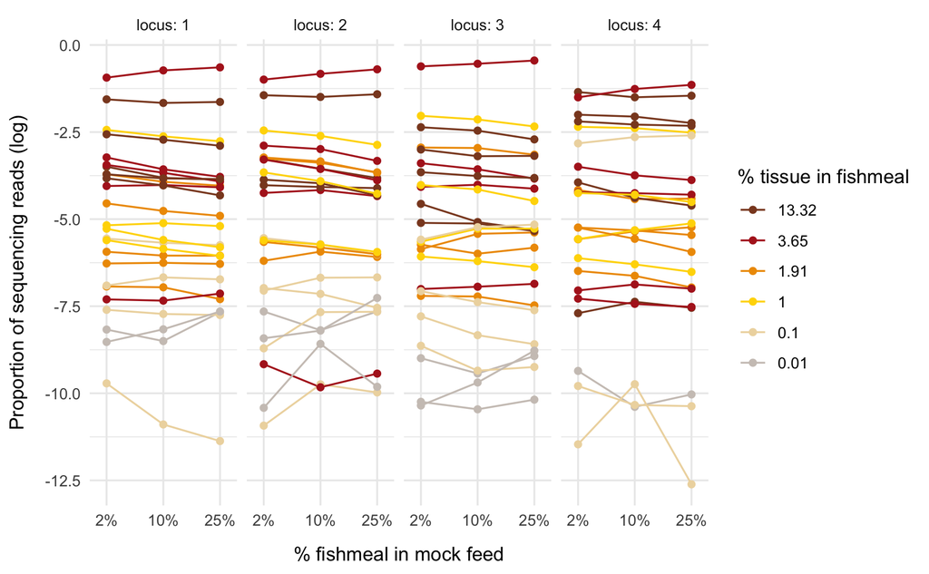

```r
new_F1_df <- feeds_prop_df  %>%
  filter(filler == "F1" & perc_fishmeal != 0) %>%
  mutate(log_mean_prop_reads = log(mean_taxa_prop)) %>%
    select(locus, species, perc_fishmeal, percent_fishmeal, log_mean_prop_reads) %>%
    pivot_wider(names_from = perc_fishmeal, names_prefix = "%fishmeal_", values_from = log_mean_prop_reads) %>%
    select(locus, species, percent_fishmeal, "%fishmeal_2", "%fishmeal_10", "%fishmeal_25")

new_F1_df$percent_fishmeal <- factor(new_F1_df$percent_fishmeal, levels = c(13.32, 3.65, 1.91, 1, 0.1, 0.01))

# plot color scheme
new.pal2 <- c("seashell3", "wheat2", "gold1", "orange2" ,"firebrick","sienna4")

# plot prep
F1plot <- ggparcoord(new_F1_df, columns = 4:6, groupColumn = "percent_fishmeal",
          scale="globalminmax",
          showPoints = TRUE) +
  theme_minimal() +
  labs(color = "% tissue in fishmeal") +
  scale_color_manual(values = rev(new.pal2)) +
  xlab("% fishmeal in mock feed") +
   scale_x_discrete(labels=c("2%", "10%", "25%"), expand = c(0.1, 0.1)) +
   ylab("Proportion of sequencing reads (log)")


F1plot + facet_grid(cols = vars(locus), labeller = label_both) +
  theme(
    axis.title.x = element_text(margin = margin(t = 10)),
    axis.title.y = element_text(margin = margin(r = 10)),
  )

ggsave("pdf_outputs/mockfeed_F1_parallel_chart.pdf", width = 10, height = 5)
```

Update: October 2020: Nina commented that there is more gray and yellow toward the bottom of the plot, which is consistent with lower tissue inputs = fewer sequencing reads. However, there are a few examples where one taxon added at 0.1% receives a surprising proportion of reads in 1-2 loci. But, there are no examples of 0.01% taxa receiving a large proportion of reads.

Can I quantify that? Maybe using the average read depth/taxa for each % tissue “bin?”

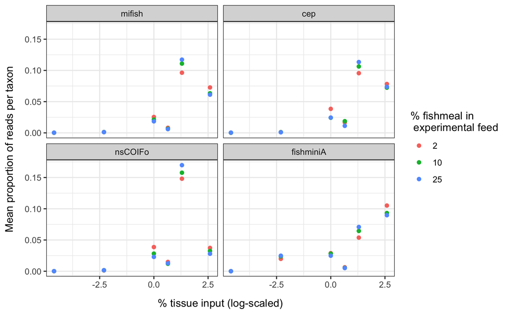

```r
feeds_prop_df  %>%
  filter(filler == "F1" & perc_fishmeal != 0) %>%
  #filter(locus == "fishminiA") %>%
  #filter(perc_fishmeal == 2) %>%
  group_by(locus, percent_fishmeal, perc_fishmeal) %>%
  summarise(mean(mean_taxa_prop)) %>%
  rename(perc_tissue_mixture = perc_fishmeal, mean_prop_of_reads_per_taxon = `mean(mean_taxa_prop)`) %>%
  ggplot(aes(x = log(percent_fishmeal), y = mean_prop_of_reads_per_taxon, color = perc_tissue_mixture)) +
  geom_point() +
  theme_bw() +
  xlab("% tissue input (log-scaled)") +
  ylab("Mean proportion of reads per taxon") +
  labs(color = "% fishmeal in \n experimental feed") +
  theme(
    axis.title.x = element_text(margin = margin(t = 10)),
    axis.title.y = element_text(margin = margin(r = 10))
  ) +
  facet_wrap(.~locus)
ggsave("pdf_outputs/SI_fig_mean_prop_reads_by_locus.pdf", width = 8, height = 6)
```

The prop. of sequencing reads does relate to the input tissue amount on an averaged basis, but not for any individual taxon.

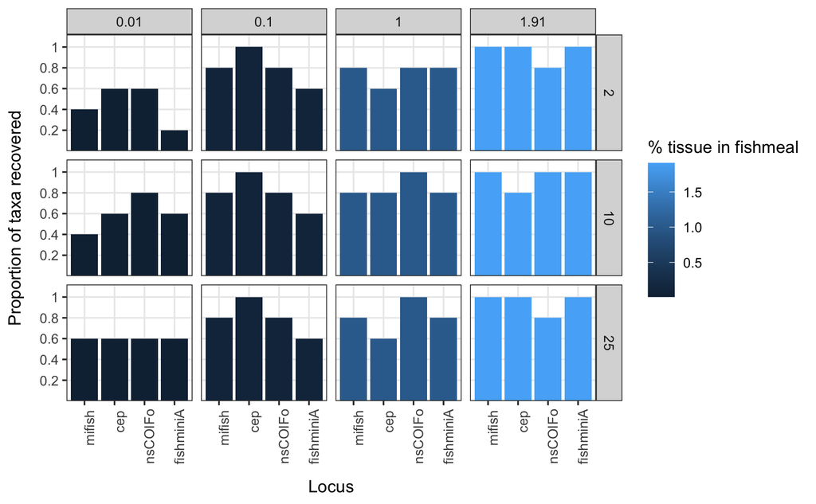

```r
mockfeed_plotct <- feeds_prop_df  %>%
  filter(filler == "F1" & perc_fishmeal != 0) %>%
  filter(percent_fishmeal < 2) %>%
  select(locus, species, perc_fishmeal, percent_fishmeal) %>%
  unique() %>%
  group_by(locus, perc_fishmeal, percent_fishmeal) %>%
  tally(name = "n_taxa") %>%
  arrange(percent_fishmeal, locus) %>%
  mutate(prop = n_taxa/5) %>%
  ggplot(aes(x = locus, y = factor(prop), fill = percent_fishmeal)) +
  geom_bar(stat = "identity", position = "dodge") +
  facet_grid(rows = vars(perc_fishmeal), cols = vars(percent_fishmeal)) +
  theme_bw() +
  ylab("Proportion of taxa recovered") +
  xlab("Locus") +
  labs(fill = "% tissue in fishmeal")

mockfeed_plotct +
  theme(
        axis.text.x = element_text(angle = 90, hjust = 0.95),
    axis.title.x = element_text(margin = margin(t = 10)),
    axis.title.y = element_text(margin = margin(r = 10))
  )
```

```r
# ggsave("pdf_outputs/mockfeed_perc_dropout_by_locus_low_tissue_input.pdf", width = 7, height = 4)
```

## Compare fillers

```r
# facet labels
fillers_df <- feeds_prop_df %>%
  filter(filler %in% c("F1", "F2")) %>%
  filter(perc_fishmeal == 25)

fillers_df$f2 <- factor(fillers_df$filler, labels = c("F1: soy", "F2: bloodmeal, feathermeal, grasses"))
```

Is this so consistent bec of the means? Or the species-amplification biases are consistent regardless of filler?

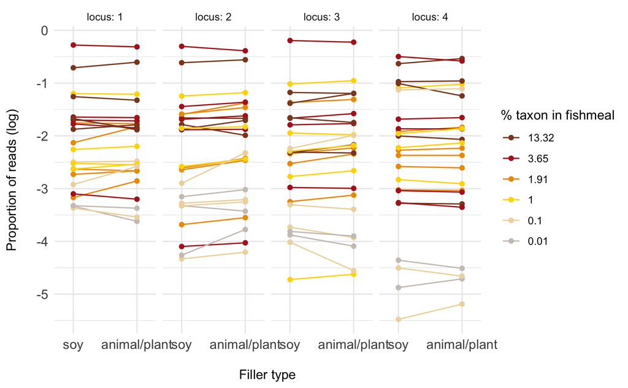

```r
# select just the columns of interest
pchart_df <- fillers_df %>%
  mutate(log_prop_reads = log10(mean_taxa_prop)) %>%
  #select(locus, species, filler, perc_fishmeal, mean_taxa_prop, percent_fishmeal) %>%
  select(locus, species, filler, perc_fishmeal, percent_fishmeal, log_prop_reads) %>%
  #pivot_wider(names_from = filler, values_from = mean_taxa_prop)
  pivot_wider(names_from = filler, values_from = log_prop_reads)

pchart_df$p_fish_in_meal <- factor(pchart_df$percent_fishmeal, levels = c(13.32, 3.65, 1.91, 1, 0.1, 0.01))

fplot3 <- ggparcoord(pchart_df, columns = 5:6, groupColumn = "p_fish_in_meal",
          scale="globalminmax",
          showPoints = TRUE) +
  theme_minimal() +
  labs(color = "% taxon in fishmeal") +
  scale_color_manual(values = rev(new.pal2)) +
  xlab("Filler type") +
  scale_x_discrete(labels=c("soy",
                        "animal/plant"), expand = c(0.15, 0.15)) +
  ylab("Proportion of reads (log)")


fplot3 + facet_grid(cols = vars(locus), labeller = label_both) +
  theme(
    axis.title.x = element_text(margin = margin(t = 15), size = 11),
    axis.title.y = element_text(margin = margin(r = 15), size = 11),
    axis.text = element_text(size = 11)
  )

ggsave("pdf_outputs/filler_parallel_chart_cols.pdf", height = 5, width = 12)
```

Check on the lowest level inputs (0.1% and 0.01%) to see if additional taxa drop out.

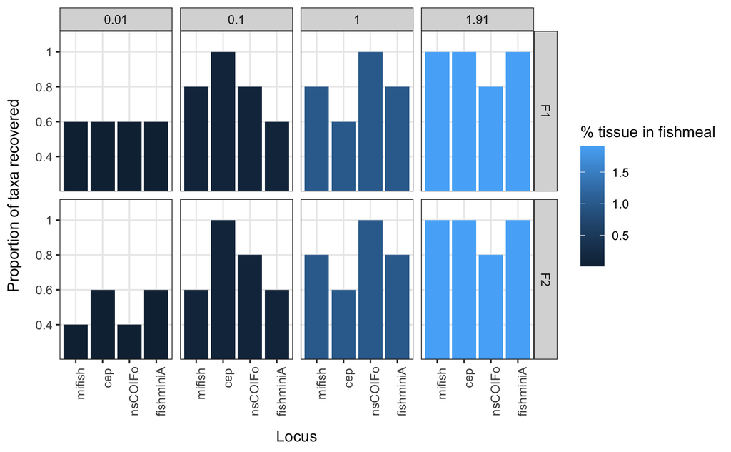

```r
fillplotct <- fillers_df %>%
  filter(percent_fishmeal < 2) %>%
  select(locus, species, filler, percent_fishmeal) %>%
  unique() %>%
  group_by(locus, filler, percent_fishmeal) %>%
  tally(name = "n_taxa") %>%
  arrange(percent_fishmeal, locus) %>%
  mutate(prop = n_taxa/5) %>%
  ggplot(aes(x = locus, y = factor(prop), fill = percent_fishmeal)) +
  geom_bar(stat = "identity", position = "dodge") +
  facet_grid(rows = vars(filler), cols = vars(percent_fishmeal)) +
  theme_bw() +
  ylab("Proportion of taxa recovered") +
  xlab("Locus") +
  labs(fill = "% tissue in fishmeal")

fillplotct +
  theme(
    axis.text.x = element_text(angle = 90, hjust = 0.95),
    axis.title.x = element_text(margin = margin(t = 10)),
    axis.title.y = element_text(margin = margin(r = 10))
  )
```

```r
#ggsave("pdf_outputs/filler_dropout_by_locus_low_tissue_input.pdf", width = 7, height = 4)
```

Each locus recovers fewer taxa at the lower % fishmeal, but they compensate for one another.

There should be 4 categories at < 2% tissue: 0.01 0.1 1 1.91

## Compare mock feed pools with feeds: proportion of sequencing reads and input amount

[output not shown]

[output not shown]